## Chapter 6: Analysis of Longitudinal Data.

In this last chapter, we will perform the analyses of the MABS at the book’s chapters 8-9. As for the chapter 8, we will utilize the `RATS` dataset, whilst for the chapter 9 we will use the `BPRS` dataset. Both dataset were transformed in long data format in the 6.1.1.Data Wrangling Exercise available [here](https://github.com/015129374/IODS-project/blob/master/Data/meet_and_repeat.R).

### 6.2.1. Analysis of Longitudinal Data I: Graphical Displays and Summary Measure Approach with the RATS dataset.

The `RATS` dataset comes from a nutrition study by Crowder and Hand (1990), on three groups of rats which were fed differently and had their weight recorded over a nine-week period. The main question is whether the growth profiles differ. After reading the table with the function `read.table()`, we factorize the variables `"ID"` and `"Group"`, and we add the variable `"Time"`, now we have the `RATS` in the long format `RATSL`:

```r
RATS <- read.table("https://raw.githubusercontent.com/KimmoVehkalahti/MABS/master/Examples/data/rats.txt", sep ="\t", header = TRUE)
library(dplyr); library(tidyr)
RATS$ID <- factor(RATS$ID)
RATS$Group <- factor(RATS$Group)
RATSL <- gather(RATS, key = WD, value = Weight, -ID, - Group) %>% mutate(Time = as.integer(substr(WD,3,4)))
```

Then we can see both the structure and the summary of long-format dataset `RATSL`:

```
## 'data.frame':    176 obs. of  5 variables:
##  $ ID    : Factor w/ 16 levels "1","2","3","4",..: 1 2 3 4 5 6 7 8 9 10 ...
##  $ Group : Factor w/ 3 levels "1","2","3": 1 1 1 1 1 1 1 1 2 2 ...
##  $ WD    : chr  "WD1" "WD1" "WD1" "WD1" ...
##  $ Weight: int  240 225 245 260 255 260 275 245 410 405 ...
##  $ Time  : int  1 1 1 1 1 1 1 1 1 1 ...
```

```
##        ID      Group       WD                Weight           Time
##  1      : 11   1:88   Length:176         Min.   :225.0   Min.   : 1.00
##  2      : 11   2:44   Class :character   1st Qu.:267.0   1st Qu.:15.00
##  3      : 11   3:44   Mode  :character   Median :344.5   Median :36.00
##  4      : 11                             Mean   :384.5   Mean   :33.55
##  5      : 11                             3rd Qu.:511.2   3rd Qu.:50.00
##  6      : 11                             Max.   :628.0   Max.   :64.00
##  (Other):110
```

We can also see the `head()` and `tail()` of the `RATSL` dataset:

```
##   ID Group  WD Weight Time
## 1  1     1 WD1    240    1
## 2  2     1 WD1    225    1
## 3  3     1 WD1    245    1
## 4  4     1 WD1    260    1
## 5  5     1 WD1    255    1
## 6  6     1 WD1    260    1
```

```
##     ID Group   WD Weight Time
## 171 11     2 WD64    472   64
## 172 12     2 WD64    628   64
## 173 13     3 WD64    525   64
## 174 14     3 WD64    559   64
## 175 15     3 WD64    548   64
## 176 16     3 WD64    569   64
```

#### Graphical Displays of Longitudinal Data.

The graphical display of longitudinal data is helpful in showing as much as raw data as possible and in unveiling different patterns such as aggregate, cross-sectional and longitudinal. It also allows for a simplier detection of unusual individuals or observations. Here we proceed in produce the first plot for all the rats in `RATSL` divided by the three groups:

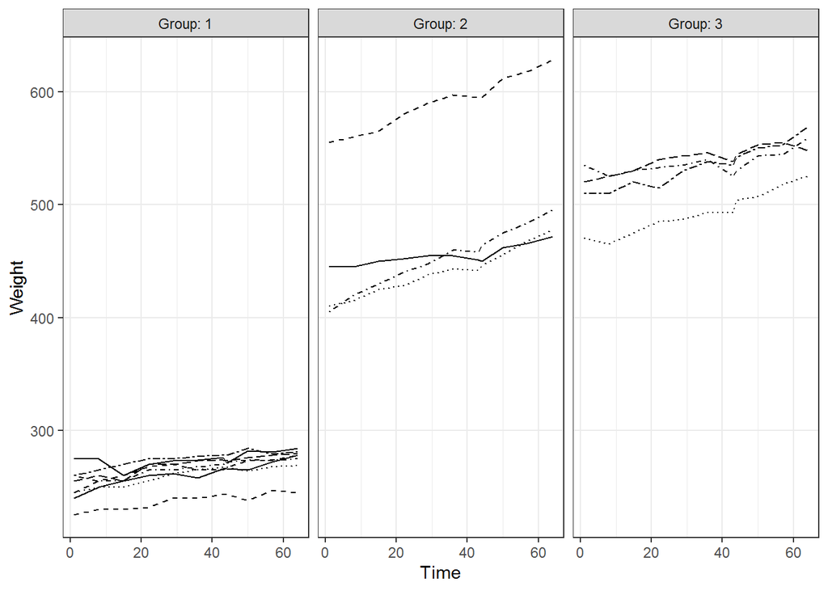

```r
library(tidyr); library(dplyr); library(ggplot2)
p1 <-ggplot(RATSL, aes(x = Time, y = Weight, linetype = ID))
p2 <- p1 + geom_line() + scale_linetype_manual(values = rep(1:10, times=4))
p3 <- p2 + facet_grid(. ~ Group, labeller = label_both)
p4 <- p3 + theme_bw() + theme(legend.position = "none")
p5 <- p4 + theme(panel.grid.minor.y = element_blank())
p6 <- p5 + scale_y_continuous(limits = c(min(RATSL$Weight), max(RATSL$Weight)))
p6
```

###### **Figure 8.1**: Individual “Weight” recordings by groups for the RATS data.

From this figure we can see that the weight has increased over the period of time for the large majority of the rats, more steeply in the `"Group 2"` and `"Group 3"`. As for the `"Group 1"` the density of the lines makes the figure difficult to read but the weight seem to have increased in a less pronounced fashion. Each group also present an outlier. From the figure it emerges also that rats with higher values at the beginning tend to have higher values throughout the study,this is the so-called phenomenon of tracking. This was the visualization of the data as they were, now we will proceed to standardize the scores:

```r
RATSL <- RATSL %>%
 group_by(Time) %>%
  mutate(stdWeight = (Weight - mean(Weight))/sd(Weight)) %>%
  ungroup()
glimpse(RATSL)
```

```
## Observations: 176
## Variables: 6
## $ ID        <fct> 1, 2, 3, 4, 5, 6, 7, 8, 9, 10, 11, 12, 13, 14, 15, 1...
## $ Group     <fct> 1, 1, 1, 1, 1, 1, 1, 1, 2, 2, 2, 2, 3, 3, 3, 3, 1, 1...
## $ WD        <chr> "WD1", "WD1", "WD1", "WD1", "WD1", "WD1", "WD1", "WD...
## $ Weight    <int> 240, 225, 245, 260, 255, 260, 275, 245, 410, 405, 44...
## $ Time      <int> 1, 1, 1, 1, 1, 1, 1, 1, 1, 1, 1, 1, 1, 1, 1, 1, 8, 8...
## $ stdWeight <dbl> -1.0011429, -1.1203857, -0.9613953, -0.8421525, -0.8...
```

After the standardization we draw the plot that visualizes the standardized `"Weight"`:

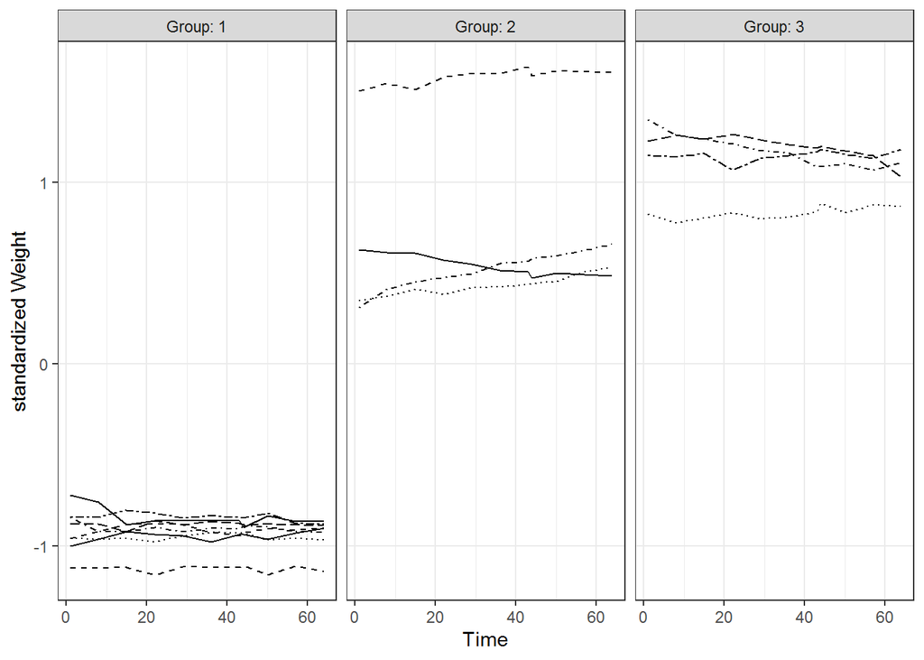

```r
p1 <-ggplot(RATSL, aes(x = Time, y = stdWeight, linetype = ID))
p2 <- p1 + geom_line() + scale_linetype_manual(values = rep(1:10, times=4))
p3 <- p2 + facet_grid(. ~ Group, labeller = label_both)
p4 <- p3 + theme_bw() + theme(legend.position = "none")
p5 <- p4 + theme(panel.grid.minor.y = element_blank())
p6 <- p5 + scale_y_continuous(name = "standardized Weight")
p6
```

###### **Figure 8.2**: Individual “Weight” recordings by groups for RATS data after standardization.

The phenomenon of tracking is more visibile from this graphic. Still, this type of visualization is not very clear. Let’s then proceed to some alternative visualization options.

#### Summary Measure Analysis of Longitudinal Data.

Within the summary measure methods there are better visualization options. The first consists in the visualization of the average weight for each group together with the indication of the variations of the observation at each timepoint. We will see this option in the **Figure 8.3**. A plotting alternative is a graph side-by-side boxplot of the observations at each time point, as in the **Figure 8.4**.

Here we have the amount of `Time`, baseline (`"WD1"`) included:

```r
n <- RATSL$Time %>% unique() %>% length()
```

The following function produces a summary data:

```r
RATSS <- RATSL %>%
  group_by(Group, Time) %>%
  summarise(mean = mean(Weight), se=sd(Weight)/sqrt(n)) %>%
  ungroup()
glimpse(RATSS)
```

```
## Observations: 33
## Variables: 4
## $ Group <fct> 1, 1, 1, 1, 1, 1, 1, 1, 1, 1, 1, 2, 2, 2, 2, 2, 2, 2, 2,...
## $ Time  <int> 1, 8, 15, 22, 29, 36, 43, 44, 50, 57, 64, 1, 8, 15, 22, ...
## $ mean  <dbl> 250.625, 255.000, 254.375, 261.875, 264.625, 265.000, 26...
## $ se    <dbl> 4.589478, 3.947710, 3.460116, 4.100800, 3.333956, 3.5529...
```

```r
RATSS
```

```
## # A tibble: 33 x 4
##    Group  Time  mean    se
##    <fct> <int> <dbl> <dbl>
##  1 1         1  251.  4.59
##  2 1         8  255   3.95
##  3 1        15  254.  3.46
##  4 1        22  262.  4.10
##  5 1        29  265.  3.33
##  6 1        36  265   3.55
##  7 1        43  267.  3.30
##  8 1        44  267.  3.07
##  9 1        50  270.  4.39
## 10 1        57  272.  3.24
## # ... with 23 more rows
```

which is then used to obtain the plot for mean `Weight`:

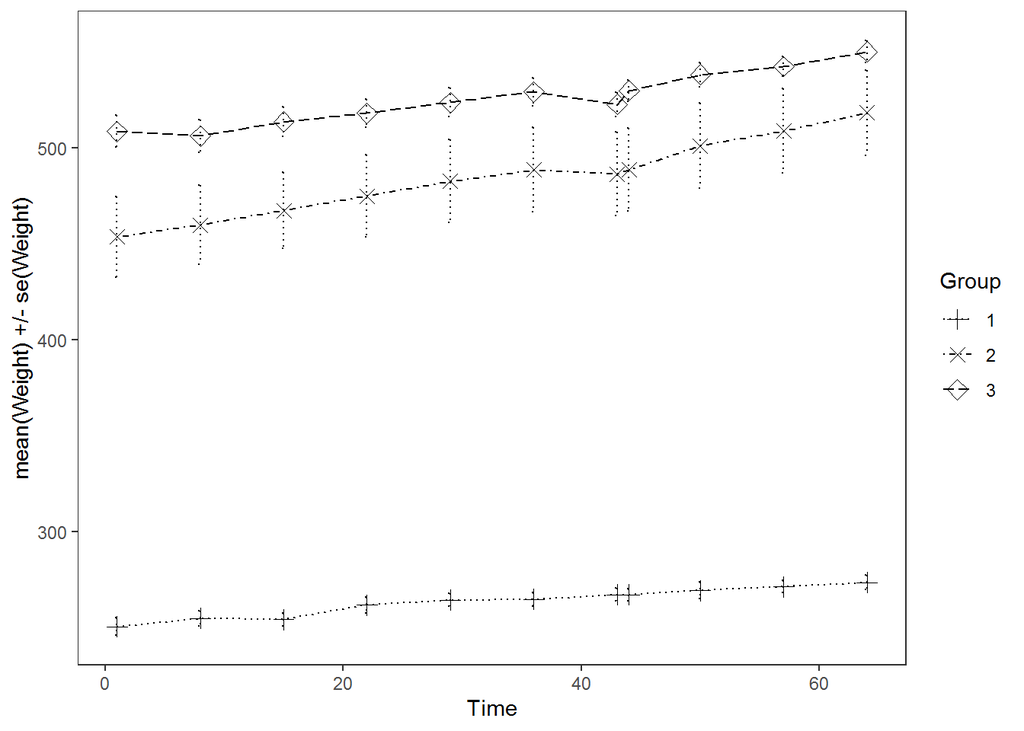

```r
p1 <- ggplot(RATSS, aes (x = Time, y = mean, linetype = Group, shape = Group))
p2 <- p1 + geom_line() + scale_linetype_manual(values = c(3:5))
p3 <- p2 + geom_point(size=3) + scale_shape_manual(values = c(3:5))
p4 <- p3 + geom_errorbar(aes(ymin=mean-se, ymax=mean+se, linetype="1"), width=0.3)
p5 <- p4 + theme_bw() + theme(panel.grid.major = element_blank(), panel.grid.minor = element_blank())
p6 <- p5 + theme(legend.position = "right")
p7 <- p6 + scale_y_continuous(name = "mean(Weight) +/- se(Weight)")
p7
```

###### **Figure 8.3**: Mean “Weight” by groups for the RATS data.

Apart from the different values in `Weight`, we can see that especially the `Group 2` and the `Group 3`, present similar dynamics in weight gaining. The `Group 1`, has a less steep weight gain and does not show the sudden drop after `WD40` as in the other two groups.

Let’s now proceed to visualize the side-by-side boxplot, which is created by executing the chunk below:

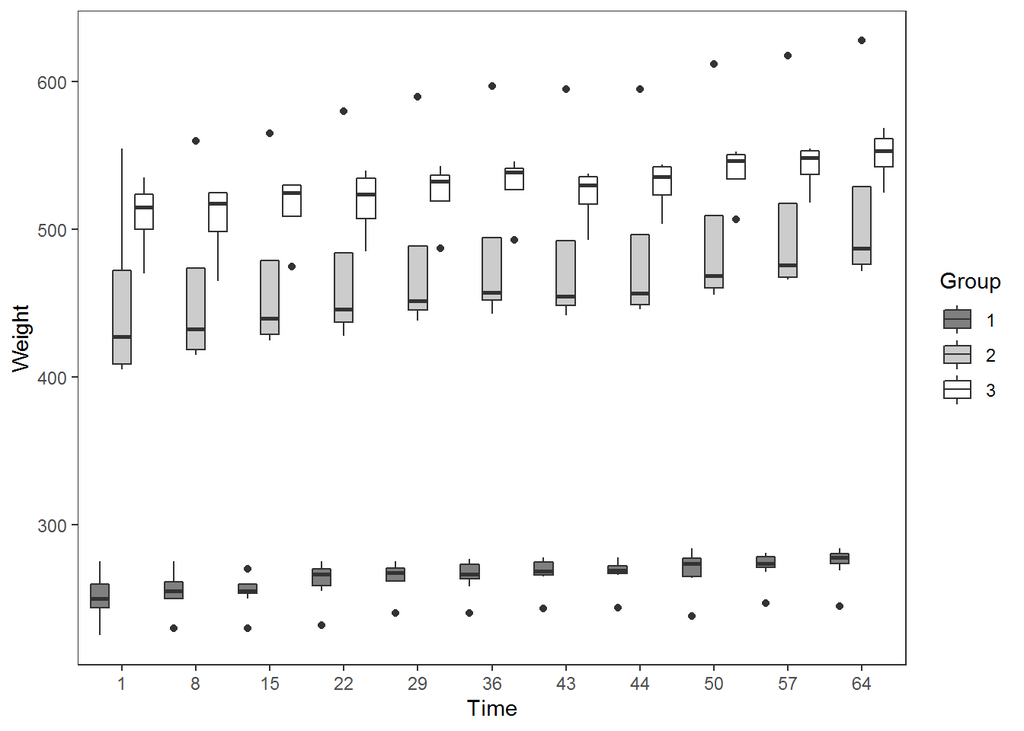

```r
p1 <- ggplot(RATSL, aes(x = factor(Time), y = Weight, fill = Group))
p2 <- p1 + geom_boxplot(position = position_dodge(width = 0.9))
p3 <- p2 + theme_bw() + theme(panel.grid.major = element_blank(), panel.grid.minor = element_blank())
p4 <- p3 + theme(legend.position = "right")
p5 <- p4 + scale_x_discrete(name = "Time")
p6 <- p5 + scale_fill_grey(start = 0.5, end = 1)
p6
```

###### **Figure 8.4**: Boxplot for the RATS data.

In here it is possible to note the outlier values for each group, of which, in the `"Group 2"` is present the highest weight. The outlier in the `Group 1` shows the lowest weight, whilst in the `"Group 3"` we find a serie of outliers that falls in the IQR of the “Group 2”```. This visualization option is certainly clearer than those represented by the **Figure 8.1** and **Figure 8.2**.

#### Applying the Summary Measure Approach.

In here we make a summary data by using the mean of the `"Time"` variable:

```r
RATSF <- RATSL %>%
  filter(Time > 1) %>%
  group_by(Group, ID) %>%
  summarise(mean = mean(Weight)) %>%
  ungroup()
glimpse(RATSF)
```

```
## Observations: 16
## Variables: 3
## $ Group <fct> 1, 1, 1, 1, 1, 1, 1, 1, 2, 2, 2, 2, 3, 3, 3, 3
## $ ID    <fct> 1, 2, 3, 4, 5, 6, 7, 8, 9, 10, 11, 12, 13, 14, 15, 16
## $ mean  <dbl> 263.2, 238.9, 261.7, 267.2, 270.9, 276.2, 274.6, 267.5, ...
```

and then we create a boxplot of the measure for each group:

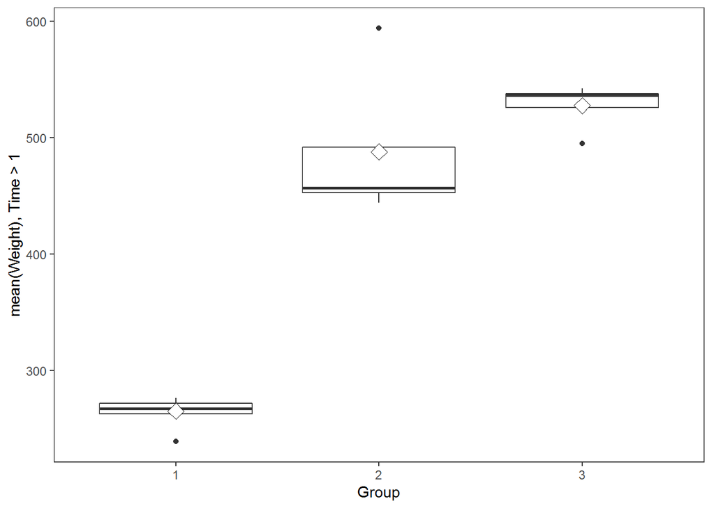

```r
library(ggplot2)
p1 <- ggplot(RATSF, aes(x = Group, y = mean))
p2 <- p1 + geom_boxplot()
p3 <- p2 + theme_bw() + theme(panel.grid.major = element_blank(), panel.grid.minor = element_blank())
p4 <- p3 + stat_summary(fun.y = "mean", geom = "point", shape = 23, size = 4, fill = "white")
p5 <- p4 + scale_y_continuous(name = "mean(Weight), Time > 1")
p5
```

###### **Figure 8.5**: Boxplot of mean summary measures for the three groups for the RATS data.

From the figure we notice that the plots for the `"Group 2"` and the `"Group 3"` are rather skewed and they present more variable means. All the group present an outlier, but especially in the `"Group 2"` the value is so high that it can bias the result.

For this reason I remove the outliers, in a rather rudimental way, after checking the values I filter them one by one:

```r
RATSFS1 <- RATSF %>%
  filter(mean < 590)%>%
  filter(mean > 239)%>%
  filter(mean != 495.2)

glimpse(RATSFS1)
```

```
## Observations: 13
## Variables: 3
## $ Group <fct> 1, 1, 1, 1, 1, 1, 1, 2, 2, 2, 3, 3, 3
## $ ID    <fct> 1, 3, 4, 5, 6, 7, 8, 9, 10, 11, 14, 15, 16
## $ mean  <dbl> 263.2, 261.7, 267.2, 270.9, 276.2, 274.6, 267.5, 443.9, ...
```

Then with the data cleared from the outliers in each class, I proceed to create the new boxplots:

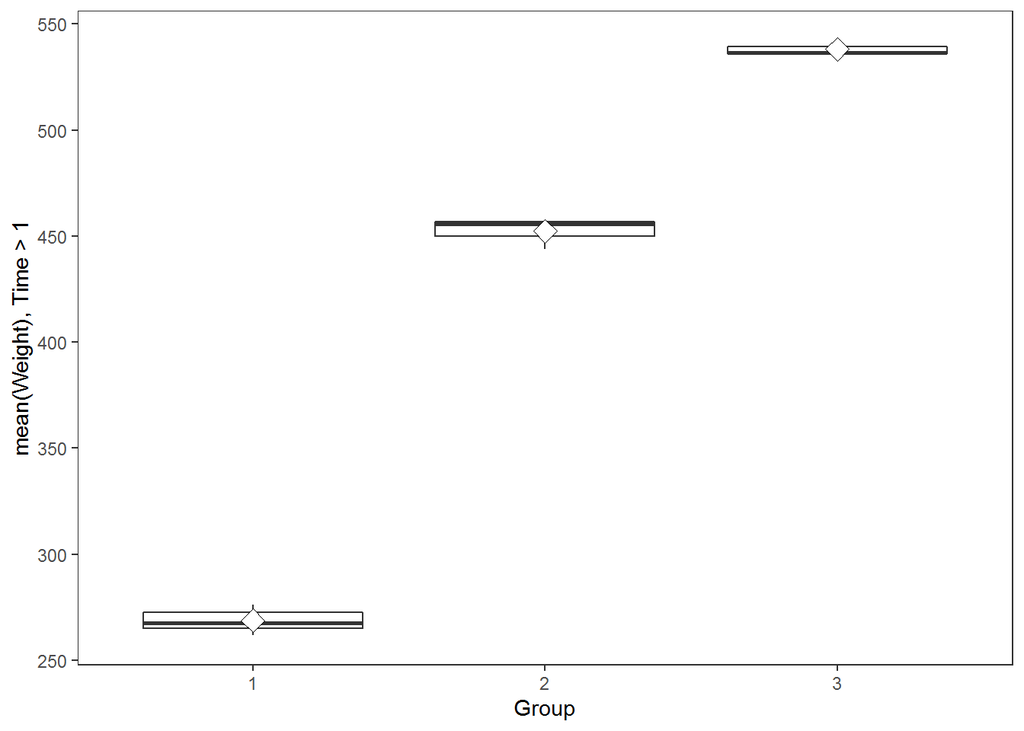

```r
p1 <- ggplot(RATSFS1, aes(x = Group, y = mean))
p2 <- p1 + geom_boxplot()
p3 <- p2 + theme_bw() + theme(panel.grid.major = element_blank(), panel.grid.minor = element_blank())
p4 <- p3 + stat_summary(fun.y = "mean", geom = "point", shape = 23, size = 4, fill = "white")
p5 <- p4 + scale_y_continuous(name = "mean(Weight), Time > 1")
p5
```

###### **Figure 8.6**: Boxplot of mean summary measures for the three groups for the RATS data, without the ouliers.

We will use the `RATSFS1` data without outliers leaving out the `"Group 1"`:

```r
RATSFS1 <- RATSFS1 %>%
  filter(RATSFS1$Group != 1)

glimpse(RATSFS1)
```

```
## Observations: 6
## Variables: 3
## $ Group <fct> 2, 2, 2, 3, 3, 3
## $ ID    <fct> 9, 10, 11, 14, 15, 16
## $ mean  <dbl> 443.9, 457.5, 455.8, 536.4, 542.2, 536.2
```

So now we run the `t.test()`:

```r
t.test(mean ~ Group, data = RATSFS1, var.equal = TRUE)
```

```
##
##  Two Sample t-test
##
## data:  mean by Group
## t = -18.235, df = 4, p-value = 5.32e-05
## alternative hypothesis: true difference in means is not equal to 0
## 95 percent confidence interval:
##  -98.94088 -72.79246
## sample estimates:
## mean in group 2 mean in group 3
##        452.4000        538.2667
```

The two groups show differences as the report indicates.

I also wanted to add the baseline weight to the `RATSLFS1` to add a bit more accuracy. However it was not possible as the `baseline` resulted `NULL`.

```r
baseline <- RATS$Time
RATSFS2 <- RATSFS1 %>%
  mutate(baseline)
```

This also prevented to fit the ANCOVA model:

```r
#fit <- lm(mean ~ baseline + Group, data = RATSFS2)

#summary(fit)
#anova(fit)
```

### 6.2.2. Analysis of Longitudinal Data II: Linear Mixed Effects Models for Normal Response Variables with the BPRS data.

Whose structure and `summary()` are the following:

```
## 'data.frame':    360 obs. of  5 variables:
##  $ treatment: Factor w/ 2 levels "1","2": 1 1 1 1 1 1 1 1 1 1 ...
##  $ subject  : Factor w/ 20 levels "1","2","3","4",..: 1 2 3 4 5 6 7 8 9 10 ...
##  $ weeks    : chr  "week0" "week0" "week0" "week0" ...
##  $ bprs     : int  42 58 54 55 72 48 71 30 41 57 ...
##  $ week     : int  0 0 0 0 0 0 0 0 0 0 ...
```

```
##  treatment    subject       weeks                bprs            week
##  1:180     1      : 18   Length:360         Min.   :18.00   Min.   :0
##  2:180     2      : 18   Class :character   1st Qu.:27.00   1st Qu.:2
##            3      : 18   Mode  :character   Median :35.00   Median :4
##            4      : 18                      Mean   :37.66   Mean   :4
##            5      : 18                      3rd Qu.:43.00   3rd Qu.:6
##            6      : 18                      Max.   :95.00   Max.   :8
##            (Other):252
```

And here are also the `head()` and `tail()` of the `BPRSL`:

```
##   treatment subject weeks bprs week
## 1         1       1 week0   42    0
## 2         1       2 week0   58    0
## 3         1       3 week0   54    0
## 4         1       4 week0   55    0
## 5         1       5 week0   72    0
## 6         1       6 week0   48    0
```

```
##     treatment subject weeks bprs week
## 355         2      15 week8   37    8
## 356         2      16 week8   22    8
## 357         2      17 week8   43    8
## 358         2      18 week8   30    8
## 359         2      19 week8   21    8
## 360         2      20 week8   23    8
```

#### Linear Mixed Effects Methods for Repeated Measures Data.

##### Fitting the Independence Model to the BPRS Data.

In here we produce the plot of `"bprs"` against `Week` for the two treatment groups:

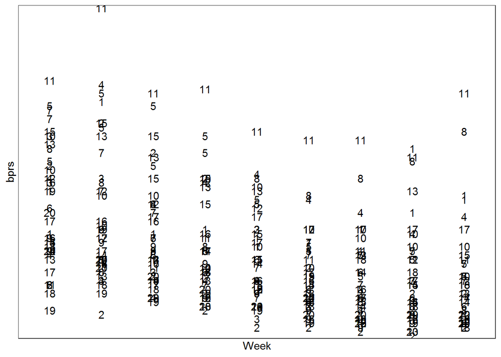

```r
p1 <-ggplot(BPRSL, aes(x= week, y = bprs, group = treatment))
p2 <- p1 + geom_text(aes(label = subject))
p3 <- p2 + scale_x_discrete(name = "Week")
p4 <- p3 + scale_y_discrete(name = "bprs")
p5 <- p4 + theme_bw()
p6 <- p5 + theme(panel.grid.major = element_blank(), panel.grid.minor = element_blank())
p6
```

###### **Figure 9.1**: Plot of bprs against weeks for treatments of the BPRSL data.

The figure is not particularly helpful in assigning each observation to its related treatment group because it contains a lot of observations. Nevertheless, it still retain some pattern which is however hard to observe. Let’s then move to fit a *linear mixed model*.

##### Fitting Linear Mixed Models to the BPRS Data.

Now we will produce a visualization of `"bprs"` values for each `"subject"`, at first we do a linear regression model to `BPRSL` with `bprs` as response variable and `treatment` and `week` as explanatory variables:

```r
BPRS_reg <-lm(bprs ~ weeks + treatment, data = BPRSL)
summary(BPRS_reg)
```

```
##
## Call:
## lm(formula = bprs ~ weeks + treatment, data = BPRSL)
##
## Residuals:
##     Min      1Q  Median      3Q     Max
## -23.714  -9.226  -2.989   6.786  48.389
##
## Coefficients:
##             Estimate Std. Error t value Pr(>|t|)
## (Intercept)  47.7139     2.0590  23.173  < 2e-16 ***
## weeksweek1   -1.6750     2.7624  -0.606  0.54467
## weeksweek2   -6.3000     2.7624  -2.281  0.02317 *
## weeksweek3   -8.8500     2.7624  -3.204  0.00148 **
## weeksweek4  -11.6500     2.7624  -4.217 3.15e-05 ***
## weeksweek5  -15.4500     2.7624  -5.593 4.51e-08 ***
## weeksweek6  -16.7750     2.7624  -6.073 3.28e-09 ***
## weeksweek7  -15.8000     2.7624  -5.720 2.29e-08 ***
## weeksweek8  -16.5750     2.7624  -6.000 4.92e-09 ***
## treatment2    0.5722     1.3022   0.439  0.66063
## ---
## Signif. codes:  0 '***' 0.001 '**' 0.01 '*' 0.05 '.' 0.1 ' ' 1
##
## Residual standard error: 12.35 on 350 degrees of freedom
## Multiple R-squared:  0.2026, Adjusted R-squared:  0.182
## F-statistic: 9.878 on 9 and 350 DF,  p-value: 1.62e-13
```

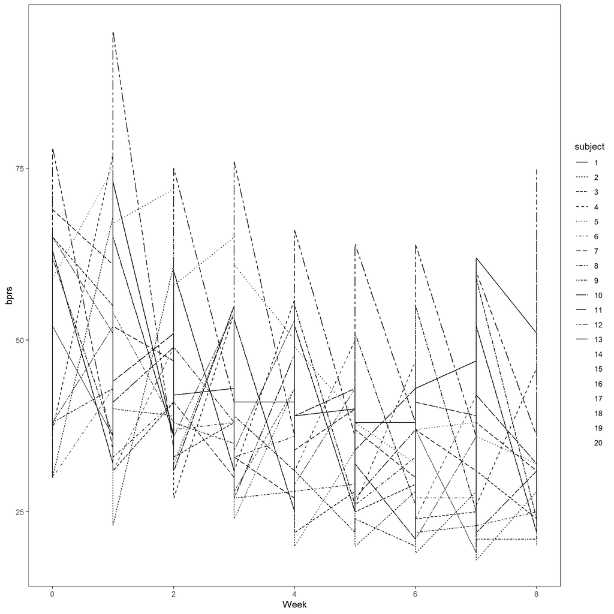

```r
p1 <- ggplot(BPRSL, aes(x = week, y =bprs, group = subject))
p2 <- p1 + geom_line(aes(linetype = subject))
p3 <- p2 + scale_x_continuous(name = "Week")
p4 <- p3 + scale_y_continuous(name = "bprs")
p5 <- p4 + theme_bw() + theme(legend.position = "right")
p6 <- p5 + theme(panel.grid.major = element_blank(), panel.grid.minor = element_blank())
p6
```

###### **Figure 9.2**: Plot of individual bprs over time.

The plot looks quite chaotic, but it shows the the decrease of the `bprs` scores over `"week"`s. As this was about the `subject`s, we can do another plot with the `"treatment"` that would result more clear.

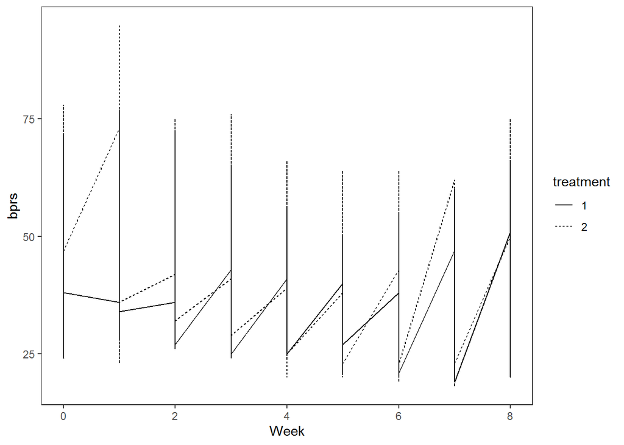

```r
library(ggplot2)
p1 <- ggplot(BPRSL, aes(x = week, y =bprs, group = treatment))
p2 <- p1 + geom_line(aes(linetype = treatment))
p3 <- p2 + scale_x_continuous(name = "Week")
p4 <- p3 + scale_y_continuous(name = "bprs")
p5 <- p4 + theme_bw() + theme(legend.position = "right")
p6 <- p5 + theme(panel.grid.major = element_blank(), panel.grid.minor = element_blank())
p6
```

###### **Figure 9.2*bis***: Plot of treatment groups’ bprs over time.

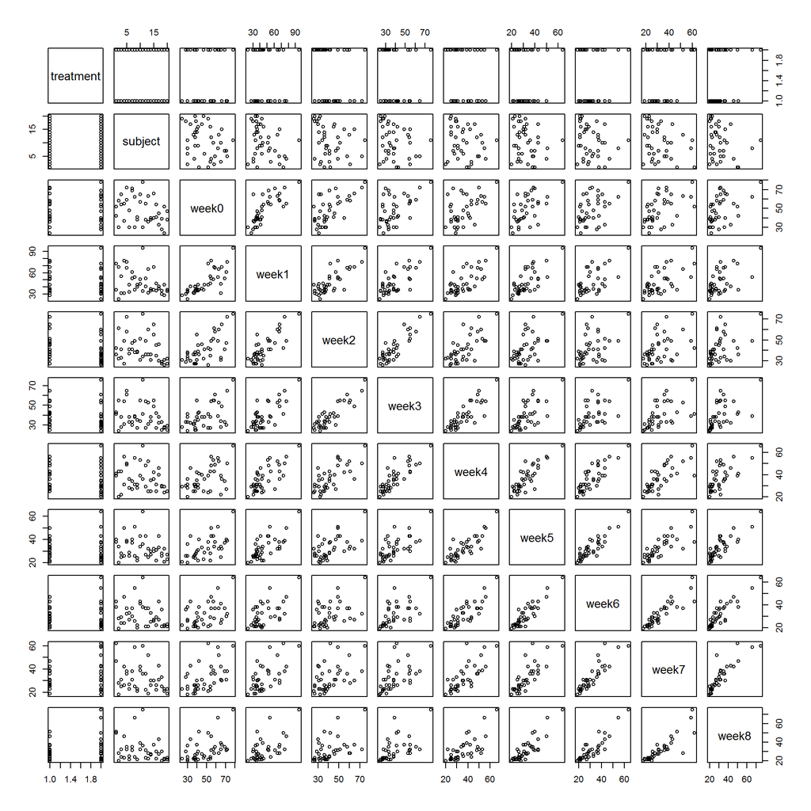

```r
pairs(BPRS, cex = 0.8)
```

###### **Figure 9.3**: scatterplot of repeated measures in subjects bprs data.

Here we have the results from **Fitting Random Intercept Model** with `week` and `treatment` as explanatory variables to the `BPRS` data:

```r
library("lme4")
BPRS_ref <- lmer(bprs ~ week + treatment + (1 | subject), data = BPRSL, REML = FALSE)
summary(BPRS_ref)
```

```
## Linear mixed model fit by maximum likelihood  ['lmerMod']
## Formula: bprs ~ week + treatment + (1 | subject)
##    Data: BPRSL
##
##      AIC      BIC   logLik deviance df.resid
##   2748.7   2768.1  -1369.4   2738.7      355
##
## Scaled residuals:
##     Min      1Q  Median      3Q     Max
## -3.0481 -0.6749 -0.1361  0.4813  3.4855
##
## Random effects:
##  Groups   Name        Variance Std.Dev.
##  subject  (Intercept)  47.41    6.885
##  Residual             104.21   10.208
## Number of obs: 360, groups:  subject, 20
##
## Fixed effects:
##             Estimate Std. Error t value
## (Intercept)  46.4539     1.9090  24.334
## week         -2.2704     0.2084 -10.896
## treatment2    0.5722     1.0761   0.532
##
## Correlation of Fixed Effects:
##            (Intr) week
## week       -0.437
## treatment2 -0.282  0.000
```

And in here there are the results from Fitting the Random Intercept and Slope Model, with `week` and `treatment` as explanatory variables in the `BPRS` data:

```r
BPRS_ref1 <- lmer(bprs ~ week + treatment + (week | subject), data = BPRSL, REML = FALSE)
summary(BPRS_ref1)
```

```
## Linear mixed model fit by maximum likelihood  ['lmerMod']
## Formula: bprs ~ week + treatment + (week | subject)
##    Data: BPRSL
##
##      AIC      BIC   logLik deviance df.resid
##   2745.4   2772.6  -1365.7   2731.4      353
##
## Scaled residuals:
##     Min      1Q  Median      3Q     Max
## -2.8919 -0.6194 -0.0691  0.5531  3.7977
##
## Random effects:
##  Groups   Name        Variance Std.Dev. Corr
##  subject  (Intercept) 64.8222  8.0512
##           week         0.9609  0.9803   -0.51
##  Residual             97.4304  9.8707
## Number of obs: 360, groups:  subject, 20
##
## Fixed effects:
##             Estimate Std. Error t value
## (Intercept)  46.4539     2.1052  22.066
## week         -2.2704     0.2977  -7.626
## treatment2    0.5722     1.0405   0.550
##
## Correlation of Fixed Effects:
##            (Intr) week
## week       -0.582
## treatment2 -0.247  0.000
```

This is the application of the ANOVA test:

```r
anova(BPRS_ref1, BPRS_ref)
```

```
## Data: BPRSL
## Models:
## BPRS_ref: bprs ~ week + treatment + (1 | subject)
## BPRS_ref1: bprs ~ week + treatment + (week | subject)
##           Df    AIC    BIC  logLik deviance  Chisq Chi Df Pr(>Chisq)
## BPRS_ref   5 2748.7 2768.1 -1369.4   2738.7
## BPRS_ref1  7 2745.4 2772.6 -1365.7   2731.4 7.2721      2    0.02636 *
## ---
## Signif. codes:  0 '***' 0.001 '**' 0.01 '*' 0.05 '.' 0.1 ' ' 1
```

Here are the results from Fitting the Random Intercept and Slope Model that allows for a `treatment` X `week` interaction to the `BPRS` data:

```r
BPRS_ref2 <-lmer(bprs ~ week * treatment + (week | subject), data = BPRSL, REML = FALSE)
summary(BPRS_ref2)
```

```
## Linear mixed model fit by maximum likelihood  ['lmerMod']
## Formula: bprs ~ week * treatment + (week | subject)
##    Data: BPRSL
##
##      AIC      BIC   logLik deviance df.resid
##   2744.3   2775.4  -1364.1   2728.3      352
##
## Scaled residuals:
##     Min      1Q  Median      3Q     Max
## -3.0512 -0.6271 -0.0768  0.5288  3.9260
##
## Random effects:
##  Groups   Name        Variance Std.Dev. Corr
##  subject  (Intercept) 64.9964  8.0620
##           week         0.9687  0.9842   -0.51
##  Residual             96.4707  9.8220
## Number of obs: 360, groups:  subject, 20
##
## Fixed effects:
##                 Estimate Std. Error t value
## (Intercept)      47.8856     2.2521  21.262
## week             -2.6283     0.3589  -7.323
## treatment2       -2.2911     1.9090  -1.200
## week:treatment2   0.7158     0.4010   1.785
##
## Correlation of Fixed Effects:
##             (Intr) week   trtmn2
## week        -0.650
## treatment2  -0.424  0.469
## wek:trtmnt2  0.356 -0.559 -0.840
```

We can then plot the fitted bprs for each subject:

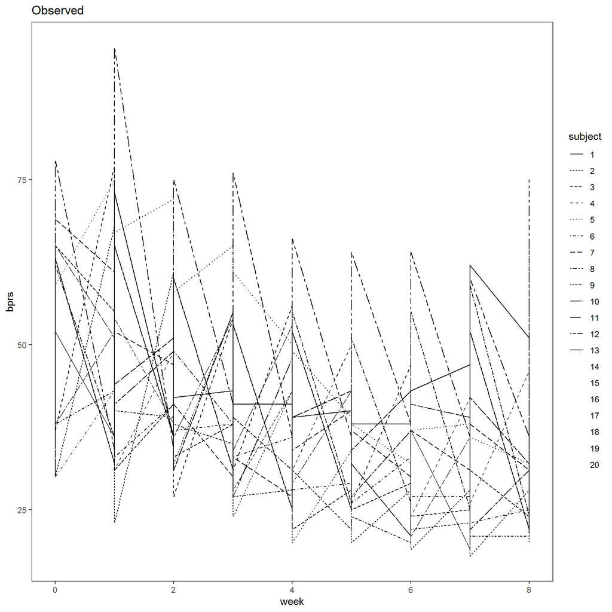

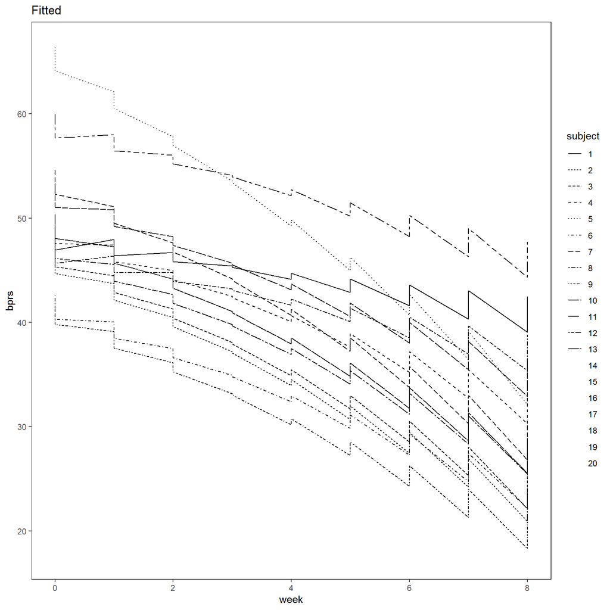

```r
Fitted <- fitted(BPRS_ref2)
BPRSL <- BPRSL %>% mutate(Fitted)

p1 <- ggplot(BPRSL, aes(x = week, y = bprs, group = subject))
p2 <- p1 + geom_line(aes(linetype = subject))
p3 <- p2 + scale_x_continuous(name = "week")
p4 <- p3 + scale_y_continuous(name = "bprs")
p5 <- p4 + theme_bw() + theme(legend.position = "right")
p6 <- p5 + theme(panel.grid.major = element_blank(), panel.grid.minor = element_blank())
p7 <- p6 + ggtitle("Observed")
graph1 <- p7

p1 <- ggplot(BPRSL, aes(x = week, y = Fitted, group = subject))
p2 <- p1 + geom_line(aes(linetype = subject))
p3 <- p2 + scale_x_continuous(name = "week")
p4 <- p3 + scale_y_continuous(name = "bprs")
p5 <- p4 + theme_bw() + theme(legend.position = "right")
p6 <- p5 + theme(panel.grid.major = element_blank(), panel.grid.minor = element_blank())
p7 <- p6 + ggtitle ("Fitted")
graph2 <- p7

graph1; graph2
```

###### **Figure 9.4**: Fitted bprs profiles from the interaction model and observed bprs profiles.